# Fyrra R verkefni

# Óskar Höskuldsson - osh16@hi.is

# Viktor Sigbjörn Víðisson - vsv8@hi.is

#### a)

#### Búið til verkefni (e. Project) í vinnumöppunni ykkar og nefnið það fyrra_r_verkefni.

#### b)

#### Lesið gagnaskrána husnaedisverd_2017.csv inn í R/RStudio og geymið í hlut sem ber upphafsstafi þeirra sem verkefnið vinna (ef Gréta Halldórsdóttir og Sigurður Jónsson eru að vinna saman skulu þau nefna hlutinn gs en ef Atli Pétursson er að vinna einn skal hann nefna hlutinn sinn ap). Kannið gerð breytanna og breytið gerð þeirra sem eru ekki af réttri gerð (ef einhverjar).

```r
ov <- read.table("husnaedisverd_2017.csv", header=TRUE, sep=";")
```

#### c)

#### Breytan kaupverd er í þúsundum króna, breytið henni þannig að hún verði í krónum.

```r
ov$kaupverd = ov$kaupverd*1000
```

#### d)

#### Búið til nýja breytu í gagnarammanum ykkar sem inniheldur fermetraverð eignanna, nefnið breytuna fermetraverd.

```r
ov$fermetraverd = ov$kaupverd/ov$birtm2
```

#### e)

#### Búið til nýja breytu sem þið skulið kalla teg_eign_groft sem byggir á teg_eign breytunni. Breytan á að innihalda tvo flokka: Sérbýli (Einbýlishús, Parhús, Raðhús) og Íbúð (Íbúðareign). Ábending: notið fct_recode() aðferðina.

```r
ov$teg_eign_groft <- forcats::fct_recode(ov$teg_eign, Sérbýli="Einbýlishús", Sérbýli="Parhús", Sérbýli="Raðhús", Íbúð="Íbúðareign")
```

#### f)

#### Búið til nýjan gagnaramma (dataframe) sem inniheldur eignir úr þremur sveitafélögum, öðrum en Reykjavík (þið veljið hvaða sveitafélög sjálf). Breytan svfn inniheldur kóða fyrir sveitafélögin. Þið sjáið í skjalinu breytur_2017.txt hvað kóðarnir standa fyrir. Kallið gagnarammann ykkar eignir.

```r
sveitarfelag <- c(1000,1100,1300)
eignir <- dplyr::filter(ov, svfn %in% sveitarfelag)
eignir$svfn[eignir$svfn == 1000] = "Kopavogur"
eignir$svfn[eignir$svfn == 1100] = "Seltjarnarnes"
eignir$svfn[eignir$svfn == 1300] = "Gardabaer"
```

#### g)

#### Breytið svfn breytunni í eignir gagnarammanum í flokkabreytu og nefnið flokkana með heiti sveitafélaganna.

```r
eignir$svfn = factor(eignir$svfn, levels=c("Kopavogur","Seltjarnarnes","Gardabaer"))
```

#### h)

#### Teiknið mynd sem sýnir fjölda eigna í sveitafélögunum þremur.

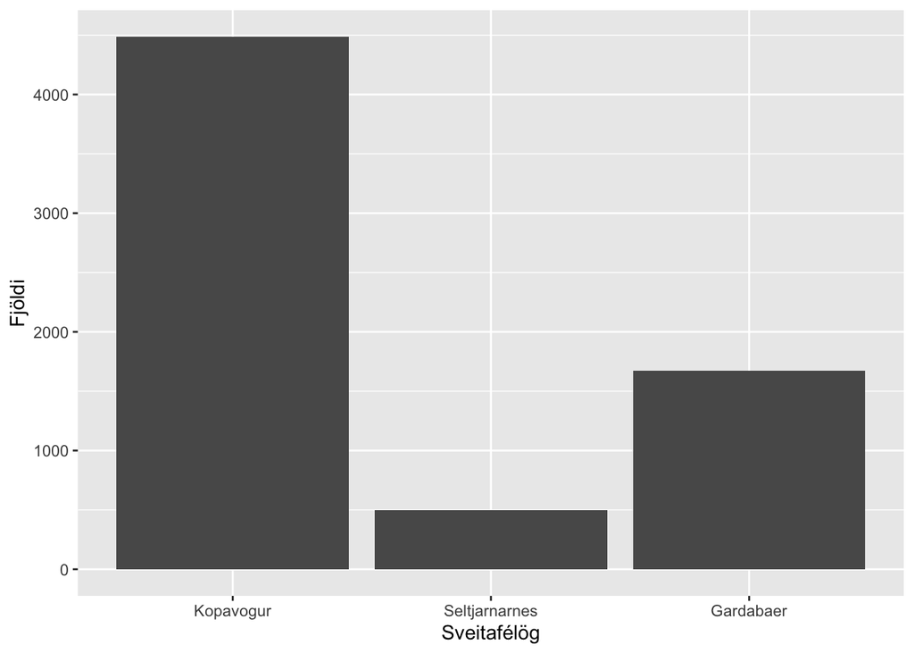

```r
ggplot(data=eignir, aes(eignir$svfn), na.rm=TRUE) + geom_bar() + labs(x='Sveitafélög', y="Fjöldi")
```

#### i)

#### Teiknið mynd sem sýnir fjölda eigna í sveitafélögunum þremur skipt upp eftir hvort eignirnar eru sérbýli eða íbúðir (þetta á að vera ein mynd, ekki skipt upp í reiti).

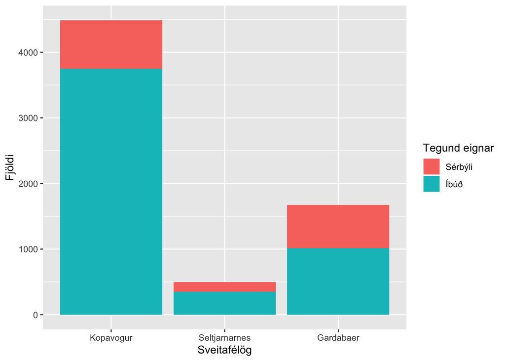

```r
ggplot(data=eignir, aes(x=eignir$svfn, fill=eignir$teg_eign_groft), na.rm=TRUE) + geom_bar() + labs(x='Sveitafélög', y= "Fjöldi", fill = "Tegund eignar")
```

#### j)

#### Teiknið mynd sem sýnir fermetraverð eigna. Teiknið aðra mynd sem sýnir kaupverð eigna. Lýsið lögun dreifinganna.

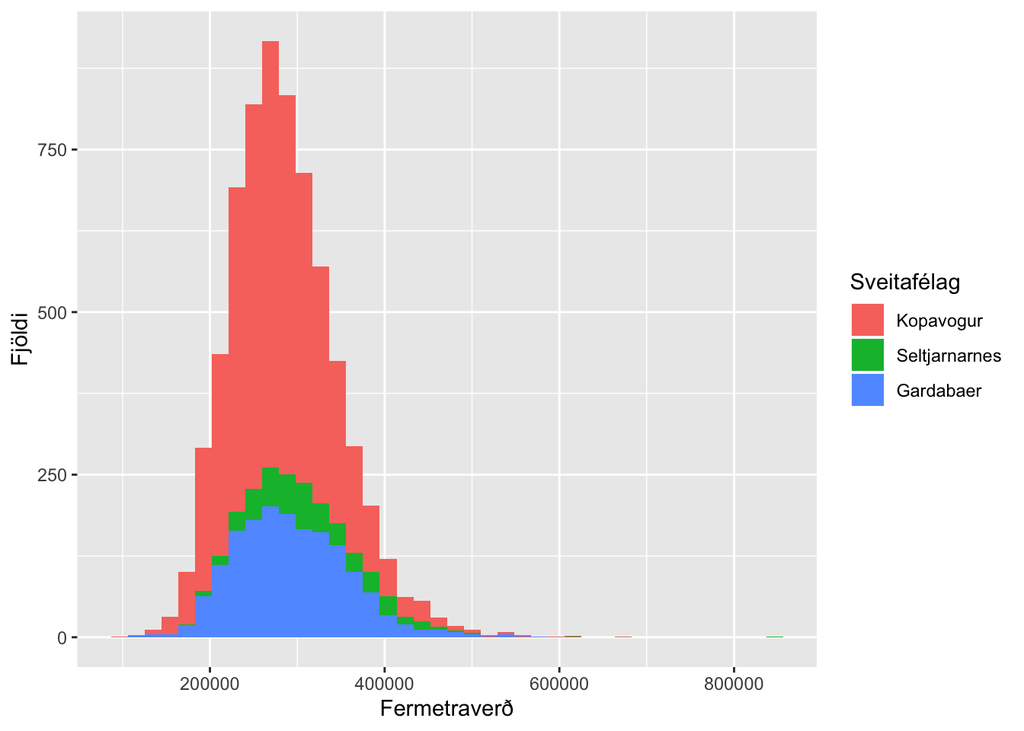

```r
ggplot(data=eignir, aes(x=eignir$fermetraverd, fill=eignir$svfn)) + geom_histogram(bins=40)  + labs(x='Fermetraverð', y= "Fjöldi", fill = "Sveitafélag")
```

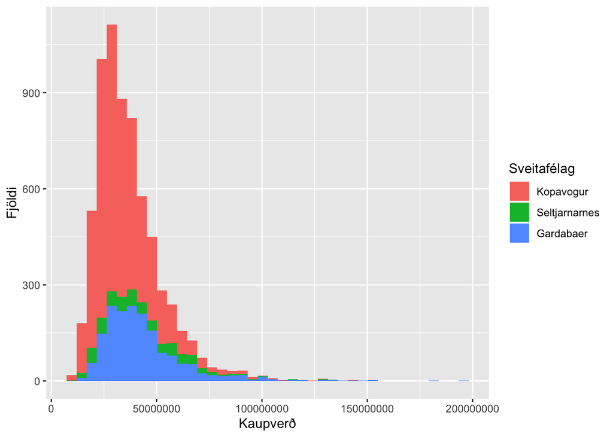

```r
ggplot(data=eignir, aes(x=eignir$kaupverd, fill=eignir$svfn)) + geom_histogram(bins=40) + labs(x='Kaupverð', y= "Fjöldi", fill = "Sveitafélag")
```

Eins og sjá má á myndunum eru gröfin fyrir fermetraverð eigna og grafið fyrir kaupverð bæði hægri skekkt einkreppudreifing.

#### k)

#### Teiknið mynd sem sýnir byggingarár eigna eftir sveitafélögum (þetta á að vera ein mynd, ekki skipt upp í reiti).

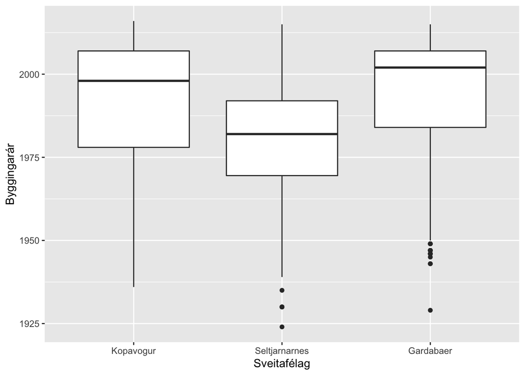

```r
ggplot(eignir,aes(x=svfn,y=byggar)) + geom_boxplot() + xlab('Sveitafélag') + ylab('Byggingarár')
```

#### l)

#### Teiknið mynd sem sýnir stærð sérbýla eftir sveitafélögum (þetta á að vera ein mynd, ekki skipt upp í reiti).

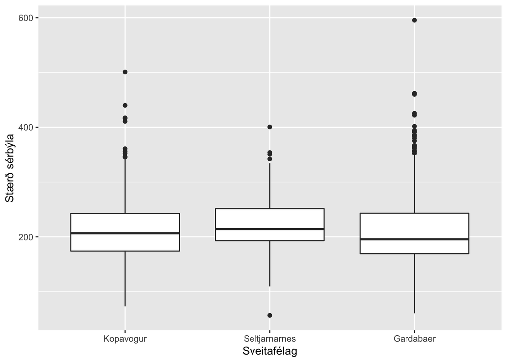

```r
serbyli = dplyr::filter(eignir, grepl("Sérbýli", eignir$teg_eign_groft))
ggplot(data=serbyli, aes(x=serbyli$svfn, y=serbyli$birtm2)) + geom_boxplot() + xlab('Sveitafélag') + ylab('Stærð sérbýla')
```

#### m)

#### Teiknið mynd sem sýnir fermetraverð íbúða eftir sveitafélögum (þetta á að vera ein mynd, ekki skipt upp í reiti).

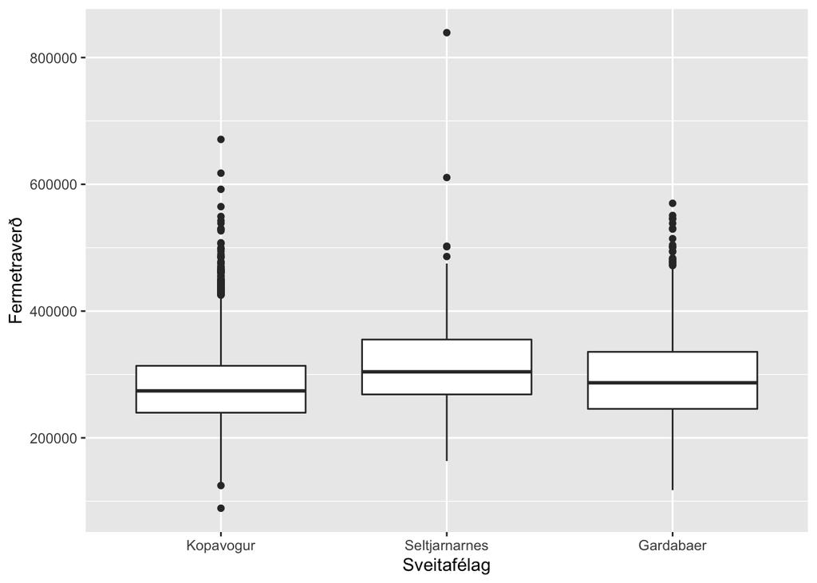

```r
ggplot(eignir,aes(x=svfn,y=fermetraverd)) + geom_boxplot() + xlab('Sveitafélag') + ylab('Fermetraverð')
```

#### n)

#### Teiknið mynd sem sýnir stærð eigna og kaupverð skipt upp eftir sveitafélögum. Myndin á að innihalda þrjá reiti, einn fyrir hvert sveitafélag (ábending: notið facet_grid() aðferðina). Notið mismunandi liti til að tákna hvort eignirnar eru sérbýli eða íbúðir.

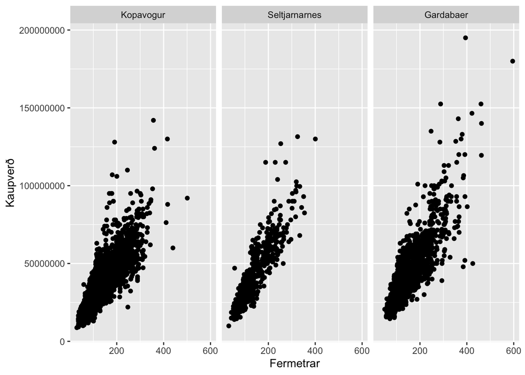

```r
ggplot(data=eignir, aes(birtm2, kaupverd)) + geom_point() + facet_grid(.~svfn) + labs(x='Fermetrar', y= "Kaupverð")
```

#### o)

#### Teiknið mynd af einhverju sem ykkur finnst áhugavert að skoða og segið í örfáum orðum hvað myndin sýnir.

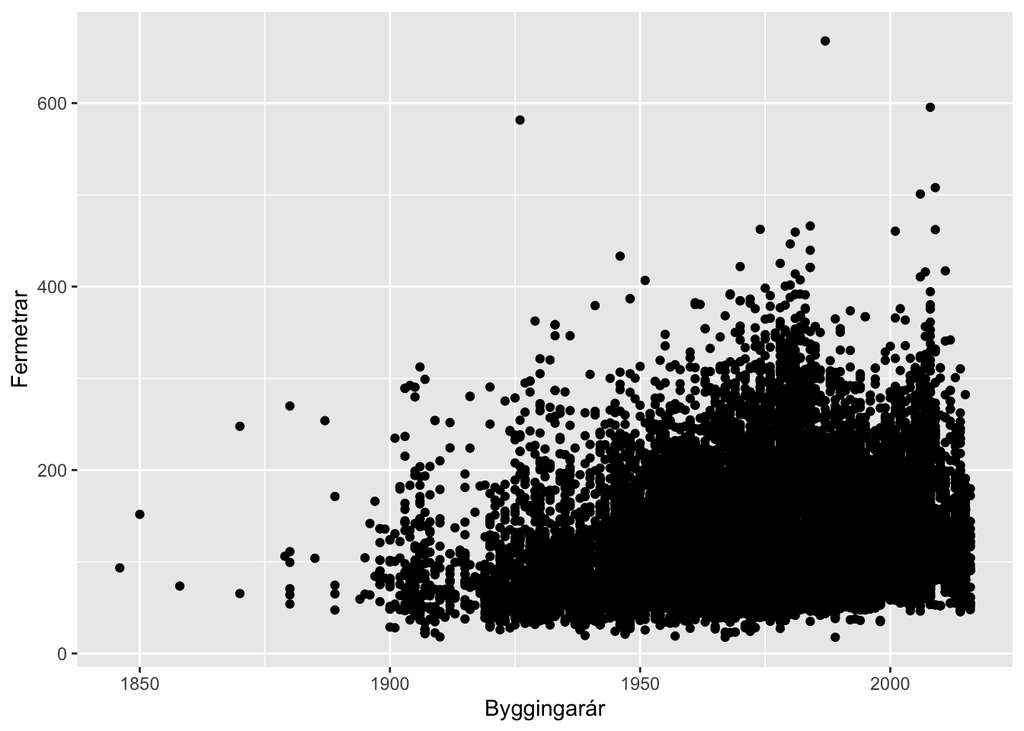

```r
ggplot(data=ov,aes(x=byggar,y=birtm2)) + geom_point() + labs(x='Byggingarár', y= "Fermetrar")
```

#### p)

#### Skrifið í samfelldu máli hvert meðaltal og staðalfrávik fermetraverðs er á eignunum í eignir gagnarammanum ykkar (eitt meðaltal og eitt staðalfrávik). Búið til hluti sem innihalda meðaltalið og staðalfrávikið og notið svo klumpakommur í textanum.

```r
medal_fverd_eignir <- mean(eignir$fermetraverd)
stadal_fverd_eignir <- sd(eignir$fermetraverd)
```

Meðaltal fermetraverðs á eignunum er 285669.033467 og staðalfrávikið er 61456.6927333

#### q)

#### Skrifið í samfelldu máli hver miðgildi byggingarárs eignanna í sveitafélögunum þremur eru (þrjú miðgildi).

```r
kop = dplyr::filter(eignir, grepl("Kopavogur", eignir$svfn))
gar = dplyr::filter(eignir, grepl("Gardabaer", eignir$svfn))
nes = dplyr::filter(eignir, grepl("Seltjarnarnes", eignir$svfn))
midgildi_byggar_kop <- median(kop$byggar, na.rm=TRUE)
midgildi_byggar_gar <- median(gar$byggar, na.rm=TRUE)
midgildi_byggar_nes <- median(nes$byggar, na.rm=TRUE)
```

Miðgildi byggingarárs í Kópavogi er 1998. Miðgildi byggingarárs í Garðabæ er 2002. Miðgildi byggingarárs á Seltjarnarnesi er 1982.

#### r)

#### Skrifið í samfelldu máli hversu margar eignir í eignir gagnarammanum ykkar eru sérbýli með tveimur baðkörum. Búið til hlut sem inniheldur fjöldann og notið svo klumpakommur í textanum.

```r
badkor <- dplyr::filter(eignir,teg_eign_groft=="Sérbýli",fjbkar==2)
serbyli_2badkor <- nrow(badkor)
```

Fjöldi sérbýla með tveimur baðkörum er 52

#### s)

#### Búið til töflu sem sýnir fjölda eigna í sveitafélögunum þremur eftir gerð eigna (sérbýli eða íbúðir).

```r
prop.table(table(eignir$teg_eign_groft, eignir$svfn))
```

```
##
##            Kopavogur Seltjarnarnes  Gardabaer
##   Sérbýli 0.11111111    0.02282282 0.09909910
##   Íbúð    0.56276276    0.05210210 0.15210210
```

```r
table(eignir$teg_eign_groft, eignir$svfn)
```

```
##
##           Kopavogur Seltjarnarnes Gardabaer
##   Sérbýli       740           152       660
##   Íbúð         3748           347      1013
```

#### t)

#### Búið til töflu sem sýnir hlutfall sérbýla og íbúða í sveitafélögunum þremur. Það á s.s. að vera hægt að lesa hver hlutfall sérbýla og íbúða er í hverju sveitafélagi fyrir sig.

```r
prop.table(table(eignir$teg_eign_groft, eignir$svfn))
```

```
##
##            Kopavogur Seltjarnarnes  Gardabaer
##   Sérbýli 0.11111111    0.02282282 0.09909910
##   Íbúð    0.56276276    0.05210210 0.15210210
```

#### u)

#### Búið til töflu sem sýnir meðaltal, miðgildi og staðalfrávik fermetraverðs skipt upp eftir sveitafélagi og tegund eigna (sérbýli eða íbúðir). Sýnið einnig fjölda eigna sem lenda í hverjum flokki í töflunni. Það á t.d. að vera hægt að lesa hvert meðalfermetraverð einbýlishúsa í sveitafélögunum þremur er og hversu mörg þau eru.

```r
eignir %>%
  group_by(svfn,teg_eign_groft) %>%
  summarise(meðaltal = mean(fermetraverd), miðgildi = median(fermetraverd), staðalfrávik = sd(fermetraverd),fjoldi=n())
```

```
## # A tibble: 6 x 6
## # Groups:   svfn [3]
##   svfn          teg_eign_groft meðaltal miðgildi staðalfrávik fjoldi
##   <fct>         <fct>             <dbl>    <dbl>        <dbl>  <int>
## 1 Kopavogur     Sérbýli         251377.  251614.       48914.    740
## 2 Kopavogur     Íbúð            285025.  279795.       58168.   3748
## 3 Seltjarnarnes Sérbýli         298095.  290816.       68950.    152
## 4 Seltjarnarnes Íbúð            321586.  314548.       67145.    347
## 5 Gardabaer     Sérbýli         271895.  268466.       55092.    660
## 6 Gardabaer     Íbúð            307907.  304753.       66366.   1013
```

#### v)

#### Búið til töflu sem sýnir meðaltal, miðgildi og staðalfrávik stærðar sérbýla skipt upp eftir sveitafélögum (hér eiga íbúðir ekki að vera með).

```r
eignir %>%
  group_by(svfn,teg_eign_groft="Sérbýli") %>%
  summarise(meðaltal = mean(birtm2), miðgildi = median(birtm2), staðalfrávik = sd(birtm2))
```

```
## # A tibble: 3 x 5
## # Groups:   svfn [3]
##   svfn          teg_eign_groft meðaltal miðgildi staðalfrávik
##   <fct>         <chr>             <dbl>    <dbl>        <dbl>
## 1 Kopavogur     Sérbýli            125.     112.         52.7
## 2 Seltjarnarnes Sérbýli            144.     131.         69.0
## 3 Gardabaer     Sérbýli            151.     131.         65.9
```